# If a Hoosier drops a pass in the end zone, but there’s no one there to see it, did it ever really happen?

# By: Jordan Majoros, Minwoo Lee, Lester Blumberg, and Joseph Spatz

As the Summer comes to a conclusion and the leaves start to change, excitement begins to grow on college campuses. After a few weeks into the fall semester, college football returns with optimistic fans eager to watch their school compete. Fans travel long distances to come back to their alma maters. The teams schedule has been examined to choose the best game to attend, whether it be the homecoming game, a top 10 opponent, or a rivalry game. Fans begin flooding campuses on Friday night or they awake early with excitement and drive the morning of the game. Almost all division one schools have big tailgating scenes hours before kickoff. Bands and cheer teams perform school traditions to build school spirit before entering the stadium. Most fans will then enter the stadium, some going in early to watch warm-ups and others right before kickoff. Their are many aspects to a college football game that draw fans to want to be in attendance. The analysis that follows will examine the different variables surrounding a college football game and see what kind of correlation they have with the number of people attending the game. We are interested in finding out what motivates a person to dedicate a large chunk of their Saturday to attending a college football game. The conclusions that can come from analyzing this dataset have uses beyond just predicting future college football attendance. They can also be used, with much care, to understand the decisions people make when attending other events, athletic and non-athletic. Another reason why this dataset is interesting to our team is that we can relate our findings to behavior we have observed in our own college experiences.

# I. Introduction

The data analyzed contains information primarily from NCAA FBS (Football Bowl Subdivision), and its Division I-A predecessor, College Football games spanning 2000 to 2018. The data is specifically the home games for the selected teams, with the corresponding attendance rates for the stadium played in. Some of the teams in the dataset have seasons included before they had reached the FBS level. For classification purposes, we list all of these teams’ conferences as being FCS for those seasons. There are 63 teams recorded, totaling 6672 home games. The columns selected include date of the game, the home team, the opponent, time of game, rank of both teams, whether the game was televised, the result of the game, stadium capacity and fill rate, whether there is a new coach, as well as the weather metrics during the game (precipitation, snowfall, snow depth, temperature maximum, and temperature minimum).

We are going to try to determine the relationships between the variables and attendance. We will also look at the relationships with attendance over the course of one season as well as over the many seasons in the sample. Have these relationships changed over time? For example, are there some predictors that had a stronger relationship earlier in the sample? How do different predictors relate to each other and interact in their relationships with attendance? Many predictors give us the opportunity to see how they might change the attendance numbers for certain teams. Which conference the team is in might have a relationship with the opponents that the home team is bring in to play. This dataset gives us a lot examine and is interesting to see what has an affect of team attendance numbers.

# II. Exploratory Data Analysis

## A. Exploring the Variables

| Variable | Description |
| --- | --- |
| Team | Name of college football team |
| Time | Start time of game |
| Opponent | Name of college team that given college is playing |
| Rank | Age of contestant |
| Site | Location of game |
| TV | Television station game is broadcasted |
| Result | Final result of game with win or loss and score |
| Attendance | Number of fans in attendance |
| Current.Wins | Number of season wins going into given game |
| Current.Losses | Number of season losses going into given game |
| Stadium.Capacity | Maximum number of fans given teams stadium can hold |
| Fill.Rate | Proportion of stadium capacity filled |
| New.Coach | Does team have a first year coach? TRUE or FALSE |
| Tailgating | Is the college rated a top 25 tailgating scene? TRUE or FALSE |
| PRCP | Amount of precipitation during game |
| SNOW | Amount of snowfall during game |
| SNWD | Depth of snow during play |
| TMAX | Maximum temperature during game |
| TMIN | Minimum temperature during game |
| Opponent_Rank | Number rank of opponent team if in top 25, NR if not |
| Conference | Division team plays in |
| Year | Year of recorded game |
| Month | Month of recorded game |
| Day | Day of recorded game |

Our attendance dataset has variables that describe the setting for each particular game. It also has numerical variables for attendance numbers and some that tell us the if their was severe weather during the time of the game. We have a lot of cateogorical variables that place teams in certain groups. In the data set, there were multiple teams that were placed into the wrong conferences at certain points in time. The data was fixed to correct this issue.

New binary category variables were created in order to analyze the data best. There are two variables that determine whether the home or away teams were ranked in the top 25 the time of the game, titled RankCoded and OppRankCoded. Another variable combined whether the game was televised or not. Then, start times of the games were condensed into whether they began during the day or the night, as opposed to individual start times in hours. Finally, a variable was created to determine if the teams were in a power conference or not.

### 1. Quantiles

```
##   25%   50%   75%
## 23411 42584 62418
```

```
##   25%   50%   75%
## 36000 52180 71799
```

```
##       25%       50%       75%
## 0.6464281 0.8485445 0.9904096
```

The median for attendance is 42584, with 25% and 75% quantiles of 23411 and 62418. For stadium capacity, we have a median of 52180 and quantiles of 36000 and 71799. Fill rate has a median of 0.8485445, a 25% quantile of 0.6464281, and a 75% quantile of 0.9904096.

### 2. Histograms

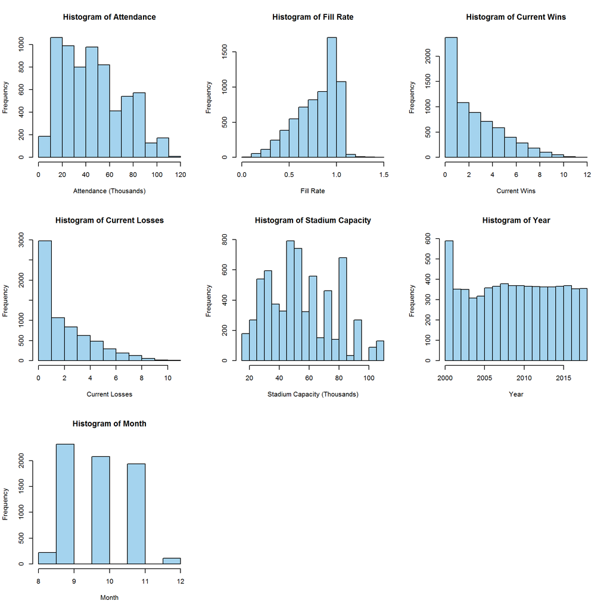

In order to understand the data provided, the variables were first analyzed in histograms. Attendance is distributed fairly evenly with most of the game attendance between 20,000 and 62,000. Fill rate sometimes exceeds 100% when some stadiums are over capacity, but there is a skew to the left. The current wins and losses both are skewed to the right, with most at 0-2. This makes sense intuitively as every team has to begin the season with 0 wins and 0 losses. Stadium capactity is seemingly distributed evenly throughout, with some peaks at different points. From 2000-2018, there are even amounts of data points for the home games, making it easier to observe trends in the given time frame. Regarding the months recorded, the games are all in the fall during the main college football season. The games that were played in April were just Memphis spring games that were somehow included in the dataset. We removed those games in order to have consistent analysis of the data. Also, one game was incorrectly marked as occurring in January instead of December, so we fixed that.

## B. Continouous Predictors

### 1. Plots

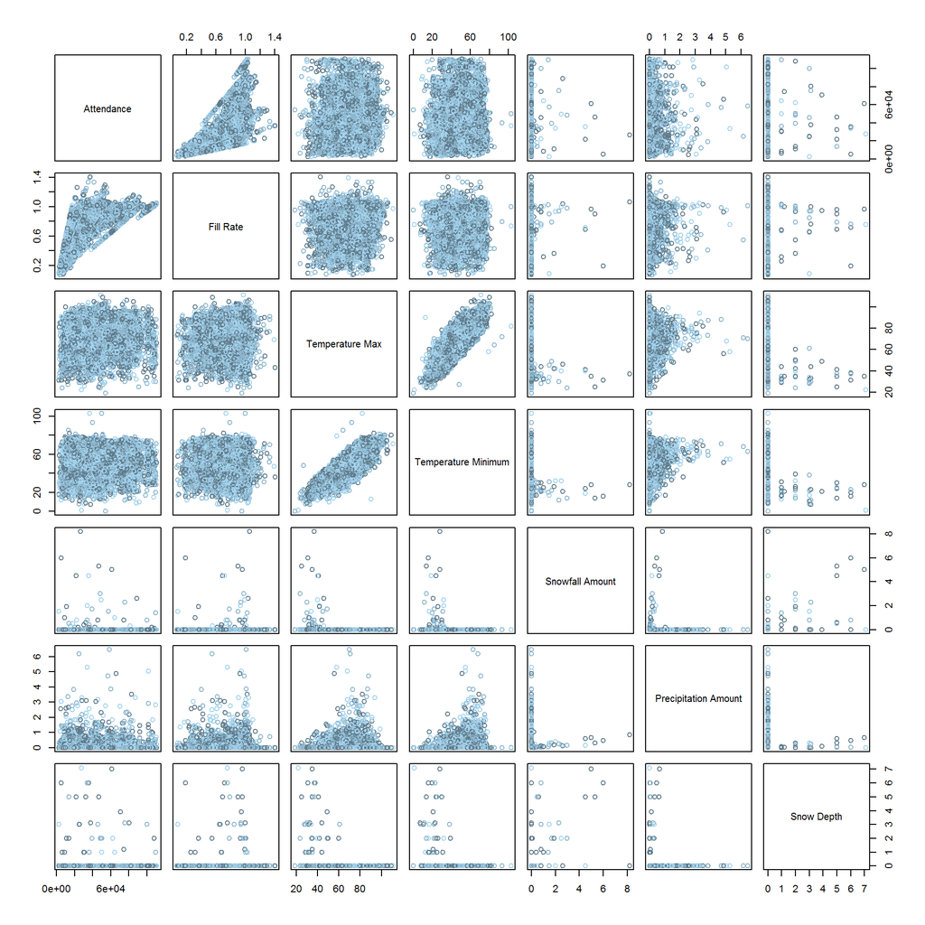

As we would expect, fill rate and attendance are very positively correlated as they are both measurements of attendance. It does not seem that temperature (either max or min) has much of a relationship with attendance or fill rate. If there is a relationship, it might be with an interaction with one or more other variables. There are not many observations of snowfall or snow depth of an inch or more, but there does appear to be a negative correlation between both measures and attendance. Negative correlations with fill rate are not as apparent from the plot, indicating that some of the correlation with attendance could be because stadiums where heavy snowfall occurred have lower than average capacities. Precipitation also looks like it has a slight negative correlation with attendance, with a correlation with fill rate less clear.

Maximum and minimum temperature obviously have a very strong positive correlation with each other. Both are also related to snowfall and snow depth as it can only snow at colder temperatures. There is also a somewhat positive relationship between temperature and precipitation.

## C. Discrete Predictors

### 1. Attendance Plots

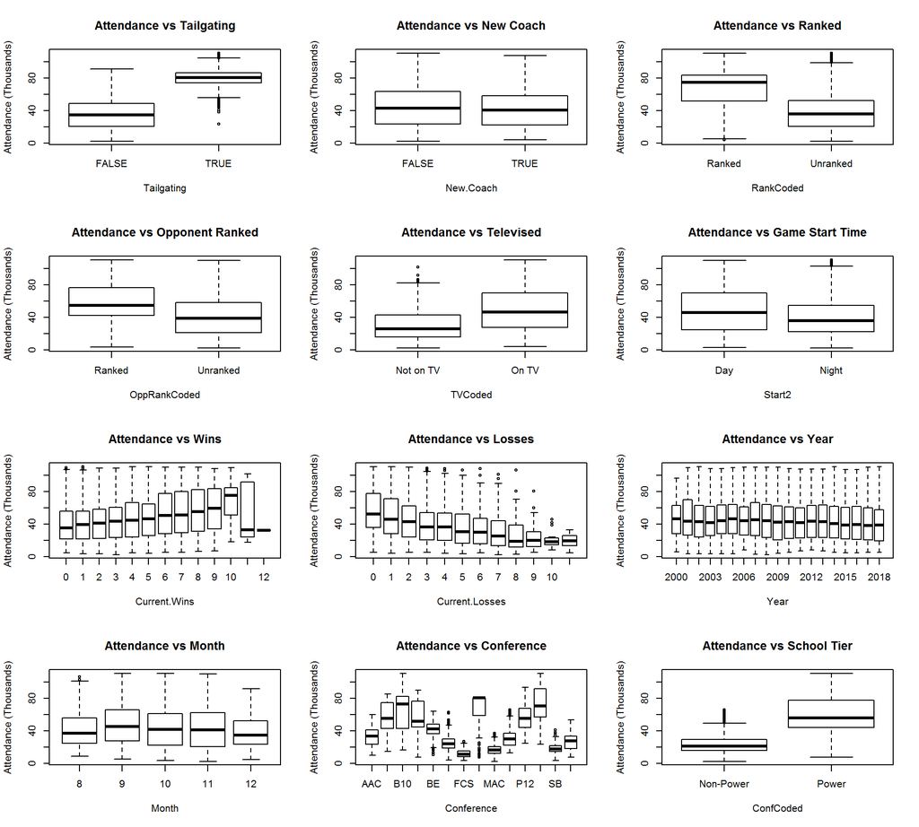

### 2. Fill Rate Plots

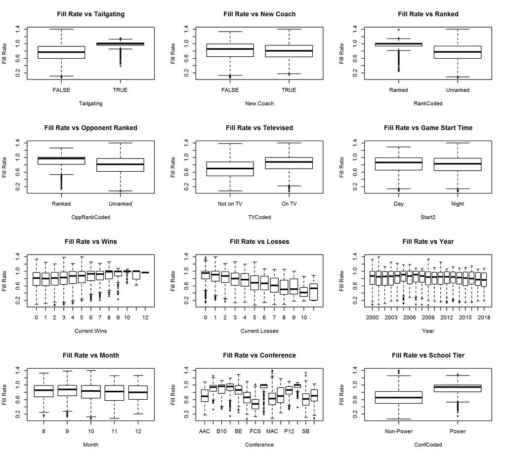

### 3. Analysis

The boxplots for the discrete variables show similar trends for both attendance and fill rate. The differences that exist between plots for a variable against attendance and fill rate illustrate the nature of the relationships between these variables.

Generally, the schools rated as being top 25 in tailgating have higher attendance than other schools. However, some of this is because these schools have larger stadiums. We can see from the fill rate boxplot that the top tailgating schools do have a higher fill rate but that the difference is not as large as the attendance chart made it look.

The differences in attendance and fill rate for schools with a new coach are small but noticeable. Schools with a new coach, on average, have lower attendance than schools with a returning coach.

Observations where either the home team or the opponent is ranked have greater attendance and higher fill rate than unranked observations.

Televised games tend to have greater attendance and fill rate than non-televised games.

Attendance tends to be higher for games that start during the day rather than games that start at night. Fill rate looks to be essentially the same for both groups of observations. It is possible that schools who tend to play home games at night more frequently have smaller than average stadiums.

As to be expected, attendance and fill rate inscrease with more wins and decrease with more losses. Weird outliers like attendance decreasing with 11 and 12 wins are due to instances of Boise State playing home games with 11 and 12 wins. Boise State has a fairly small stadium capacity.

Attendance and fill rate have both decreased over the years in the sample, with both on a mostly steady decline since 2005-2007.

Both measures decrease by month from September through November. It is harder to draw conclusions about August or December as there are only 220 observations in August and 111 observations in December out of the 6662 total observations in our sample dataset.

We can observe a sort of heirarchy in conference attendance and fill rate, with the SEC having the highest fill rates of any conference. Independents have good attendance and fill rate largely due to Notre Dame, one of the most popular college football teams, being one of a small number of independent schools. Not surprisingly, schools in the lower FCS classification (or something similar like Division I-AA), had very low attendance and fill rates. When we separate the schools into the power conferences (plus Notre Dame) and non-power conferences, we see a stark difference in attendance and a noticeable difference in fill rate too.

# III. Results and Analysis

## A. Modeling

We have split our data into two groups. Half of the observations are part of our selection set, which we will use to fit models. The other half will make up our inference set, which we will use to run diagnostics on our chosen models and determine if the models are flawed.

After examining many models, we have determined that our preferred model for attendance is `att.gam7`, an additive model which includes current wins, current losses, stadium capacity, minimum temperature, maximum temperature, and factors for tailgating, rank, opponent rank, and school tier as predictor variables. It has the lowest root mean squared error of our fitted models, 8056.043

Similarly, our preferred fill rate model, `fill.gam7`, is an additive model which includes the same predictors as our preferred attendance model, plus a factor for whether the game starts in the day or at night. It has the lowest root mean squared error of our fitted fill rate models, 0.1602213

## B. Inference/Results

### 1. Attendance Residuals

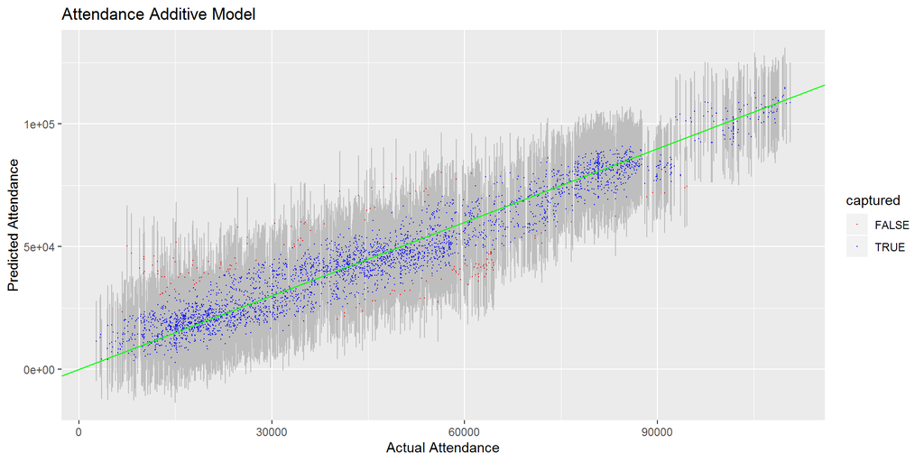

In our residual plot of predicted values against observed, we see fairly constant error variance throughout. At smaller observed values, we see that our model is more likely to overpredict attendance rather than underpredict.

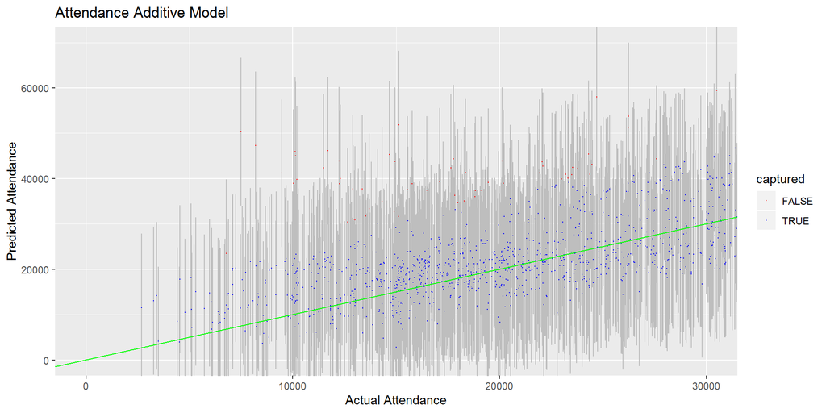

Zooming in on this region allows us to examine this closer. It does not seem to be too bad of a problem. We are still fairly confident in our attendance model.

### 2. Fill Rate Residuals

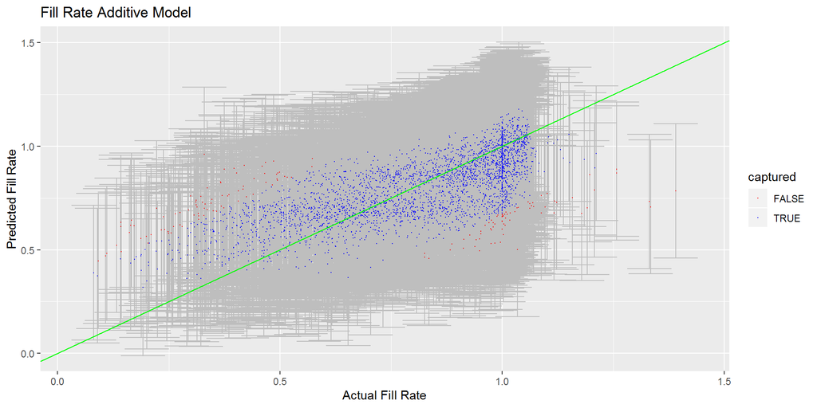

The residual plot for our fill rate model shows worse skew than our attendance model. It overpredicts low fill rates and underpredicts high fill rates. It is possible that there is something important that our model is failing to capture.

### 3. Attendance Coefficients and Partial Response Functions

We have a table of coefficients for our categorical variables while we need plots of the partial response functions to see the relation between our smoothed variables and the response.

|  | x |
| --- | --- |
| (Intercept) | 41177.677 |
| TailgatingTRUE | 9953.579 |
| RankCodedUnranked | -2675.806 |
| OppRankCodedUnranked | -3277.806 |
| ConfCodedPower | 11094.498 |

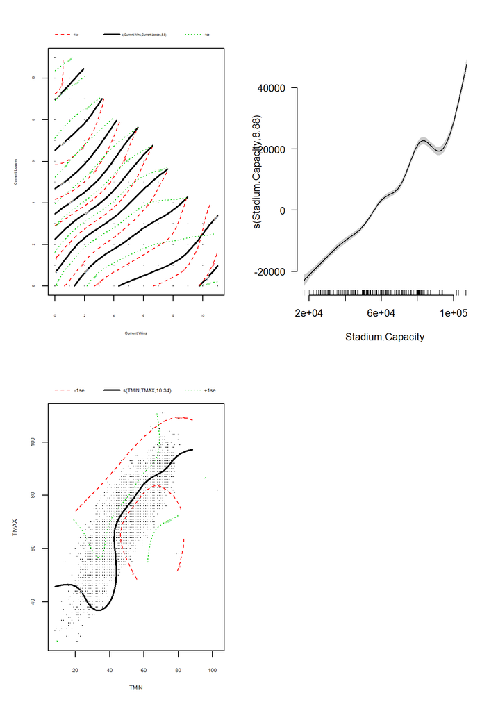

### 4. Fill Rate Coefficients and Partial Response Functions

We also produce the coefficient table and partial response function plots for our fill rate model.

|  | x |
| --- | --- |
| (Intercept) | 0.6947550 |
| TailgatingTRUE | 0.1169799 |
| RankCodedUnranked | -0.0253476 |
| OppRankCodedUnranked | -0.0530696 |
| Start2Night | 0.0356299 |
| ConfCodedPower | 0.2068212 |

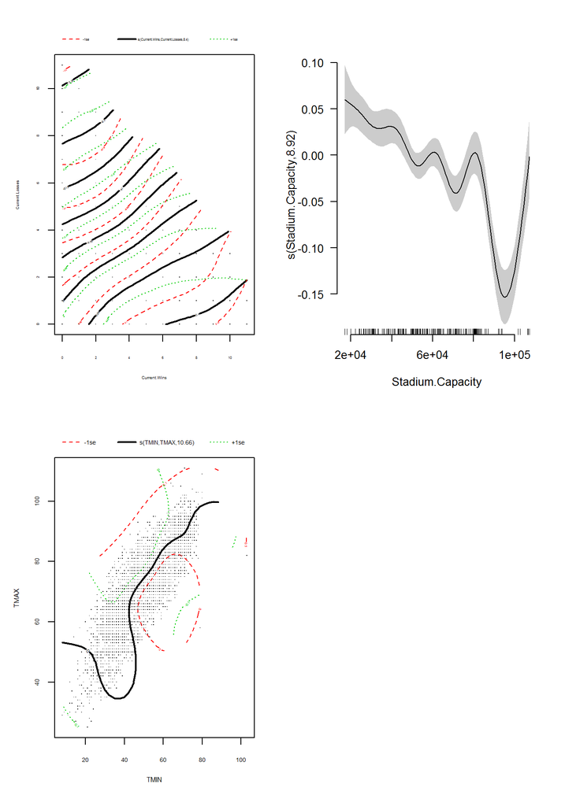

# IV. Final Discussions and Results

In conclusion, a final model was created that used the available data to predict attendance and stadium fill percentages effectively. This model smoothed the current wins and losses of the home team together to have the effect of a variable that represented the team’s overall record at the time of the game. The stadium capacity was smoothed, as well as the maximum and minimum temperatures smoothed together. The smoothing of temperature data together improved the model’s accuracy compared to models that smoothed the two separately. The variables of whether the school was a top 25 tailgating location, the ranks of both of the teams playing, and if the home team was in a power conference (or Notre Dame), were added. For the fill rate model, we also included a variable for whether the game started during the day or at night.

Being a top 25 tailgating location, being ranked, the opponent being ranked, and being in a power conference all resulted in greater attendance and higher fill rates. Games starting at night also resulted in higher fill rates. While greater stadium capacity obviously resulted in greater observed attendances, it had a negatively observed relationship with fill rate.

Generally speaking, the better home team records (more wins than losses) result in greater attendance and higher fill rates. Interestingly, our models imply that the attendance penalty for losing is more severe than the reward for winning. The zero ridge of no increase or decrease in attendance starts not at a 0-0 record but a 0-1. However, it trends faster towards wins than losses; for example a 6-4 record produces no net change in attendance. Similarly, a .500 record (same number of wins as losses) results in larger negative swings in attendance with more games played. This effect may be somewhat due to the skewed distribution of fill rates. As we observed in our histogram of fill rates, they are more heavily concentrated at fill rates near 100%, with very few below 50%. It stands to reason that any team already drawing close to 100% attendance can only increase attendance so much by winning more while even a team drawing at 50% has plenty of room to fall.

There is not as strong of a relationship between the temperature and attendance. In smoothing them together we saw that the zero ridge for attendance is found roughly when the maximum temperature is about 15-20 degrees greater than the minimum temperature. Larger differences correlated with greater attendance and smaller differences with worse attendance, but this is not as pronounced as the smoothing of wins and losses.

It was interesting to observe, that in general testing of models, that when whether a game was televised was included as a variable, while not significant, there was a slight positive correlation. As the dataset includes many years when there were not as many televised games each week, this might be a reflection that larger, better, and more popular programs are overrepresented in the sample of televised games. There is a common claim that the availability of games being televised affects attendance negatively, as people can watch from their preferred locations of their house or a local sports bar for example. However, this was not seen throughout the modeling processes. It is possible, that the increase of televised games and streaming services might hurt attendance throughout the country, but that would need more reasearch and analysis in the future.

While this model did not aid in the question as to why attendance has been decreasing for over 10 years, it did significantly help with the prediction of attendance rates per specific games. There are speculations as to the large decrease in attendance, which include the increase of price of tickets as well as the increase of cost of education and life for students at universities. These variables would be beneficial if they were recorded and included in future models, to possibly see the relationship over time with university life and attendance.